# Bowman Field Weather_01_Importing and Cleaning Data

## Louisville Weather Time Series Analysis

There is a lot of news about climate change and strange temperatures this year. In some areas with have the “bomb cyclone”, and in other we have drought conditions. Living in Louisville I decided to take some time to see what the local data actually shows about trends in weather.

For this analysis I will be using a few packages which you will need loaded in order to follow along:

```r
# List of packages to load:
packages <- c("tidyverse", "lubridate", "tibbletime", "rlang", "dygraphs", "forecast", "zoo", "xts", "stringr")

# Check to see whether any packages aren't installed on the computer and install
new_packages <- packages[!(packages %in% installed.packages()[,"Package"])]
if(length(new_packages)) install.packages(new_packages)

# Load Neccessary Packages
sapply(packages, require, character.only = TRUE)
rm(new_packages)
```

## Data Collection and Import

The National Climate Data Center (NCDC) and National Centers for Environmental Information (NCEI) provides access to hourly weather data from the National Oceanic and Atmospheric Administration (NOAA) at https://www7.ncdc.noaa.gov/CDO/cdopoemain.cmd?datasetabbv=DS3505&countryabbv=&georegionabbv=&resolution=40 (Valid as of 02/04/2018 but slated for obsolecense in May of 2018). This form is the fastest way to get clean data. The link automatically cleans the data into a person readable format. So for ease of use I put in a request for the data I wanted and then downloaded the txt files.

- Bowman Field Airport is Station ID 72423513810 and has data from 11/1941 to 02/2018 with a gap from 2000 to 2003.
- Bownam Fld is Station ID 72423599999 and has data from 01/2000 to 12/2003.

### Downloading data from the site

After a few minutes the website processed process the file and send an email. Download the file to the working directory and then import the data to R.

```r
# Load Bowman Field Weather Data
bf.file1 <- c("1973_01_01-2018_01_01-BowmanField.txt")
bf.file2 <- c("2000_01_01-2003_12_31-BowmanField.txt")
bf.df1 <- read.delim(bf.file1,header=TRUE, sep = "", as.is = TRUE, fill = TRUE)
bf.df2 <- read.delim(bf.file2,header=TRUE, sep = "", as.is = TRUE, fill = TRUE)
bf.df <- full_join(bf.df1,bf.df2)
rm(bf.file1,bf.file2,bf.df1,bf.df2)

# Make the YR..MODAHRMN easier to read
colnames(bf.df)[3] <- "DATE_TIME"

# Arrange Bowman Field Data by date because we are merging two sets of date data
# and need the dates to be in ascending order
bf.df <- bf.df %>% arrange(DATE_TIME)
gc(verbose = TRUE)
```

### Clean up values that have special meaning

Some of the values are non-numeric and have special meaning.

In the cloud ceiling column the value 722 means unlimted (aka no cloud ceiling).

In all columns a * represents an NA value.

```r
clean_ncdc_df <- function(in.df) {
  # Replace CLG values of 722 with Inf because of documentation
  in.df[in.df[,"CLG"]=="722","CLG"] <- Inf

  # Replace missing values marked by * with NA
  for(col in names(in.df)) {
    in.df[,col] <- str_replace_all(in.df[,col],"^[*]+$","NA")
    in.df[in.df[,col]=="NA",col] <- NA
  }


  # Replace DIR values of 990 with NA. This means Variable...but we can't analyze variable.
  # Unsure why some values are over 360. Can either use value %% 360 or can turn into NA.
  # Using NA because unsure what the meaning is.
  in.df[(is.na(in.df[,"DIR"])) | (in.df[,"DIR"] > "360"),"DIR"] <- NA

  # Done
  return(in.df)
}

bf.df <- clean_ncdc_df(bf.df)

rm(clean_ncdc_df)
```

### Fix variable types in the data

Two operations need to be performed to fix the variables types.

First, the DATE_TIME field should be in date format.

Second, the numeric items should be in numeric format

- Note: Any fields with a character will be coerced to NA. In this case it is a good thing because a character in a numeric field indicates there was some anomaly with the data.

```r
bf.df$DATE_TIME <- ymd_hm(bf.df$DATE_TIME)

# The following fields are numberic data (or close enough)
numeric.var <- c("USAF", "WBAN","DIR","SPD","GUS","CLG","VSB","TEMP","DEWP","ALT","PCP01","SD")
for(col in numeric.var) {
  bf.df[col] <- as.numeric(unlist(bf.df[col]))
}
rm(numeric.var)
```

### Only keep the columns needed for the analysis

For this analysis we will only be using numeric data. We will keep:

- Date/Time (the time index…)
- Temperature
- Dewpoint
- Wind Direction
- Wind Speed
- Gust Speed
- Cloud Ceiling
- Visibility
- Precipitation in Previous Hour

```r
colsToKeep <- c("DATE_TIME","TEMP","DEWP","DIR","SPD","GUS","CLG","VSB","PCP01")
bf.df <- bf.df %>% select(colsToKeep)
rm(colsToKeep)
```

### Make this into a tibbletime object for analysis

Converting into a tibbletime object is apparently the new way to use time series in R as of early 2018.

```r
bf.tt <- as_tbl_time(bf.df,index = DATE_TIME)
```

Now let’s plot some of the data to make sure this is working. Let’s start with temperature because it is realatively clean data.

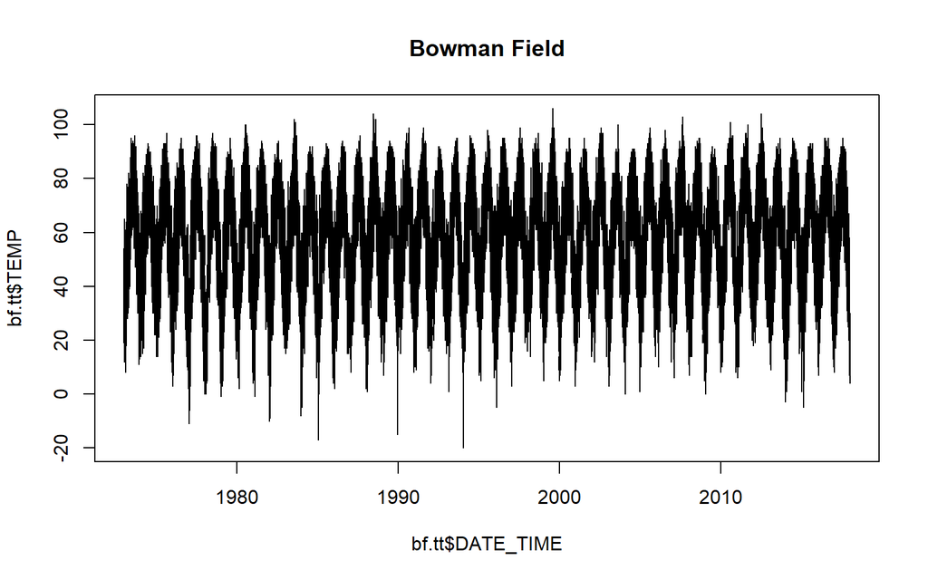

```
## integer(0)
```

```r
#par(mfrow=c(2,1))
plot(x = bf.tt$DATE_TIME, y = bf.tt$TEMP, type = "n", main = "Bowman Field") +
  lines(x = bf.tt$DATE_TIME, y = bf.tt$TEMP)
```

## Prepare data for Time Series Analysis

### Make the data set regular

Many time series functions use integer inputs to determine the length of a period. For example: one year is 365 daily values, one year is 24*365.25 hourly values, etc. Because these functions use an integer number of values as a period, any missing or extra values will cause problems. For instance, what happens if one year has exactly 385 daily values, but another year has 300 daily values? If we perform a moving average with a window of a 365 days there will be problems in the moving average.

#### Check for regular data

Let’s first see if there are any missing hours in a year.

```r
bf.tt %>%
  collapse_by('yearly') %>%
  group_by(DATE_TIME) %>%
  select(DATE_TIME,TEMP) %>%
  summarise(length = length(TEMP))
```

| DATE_TIME | length |
| --- | --- |
| 1973-12-31 23:00:00 | 8360 |
| 1974-12-31 22:00:00 | 8109 |
| 1975-12-31 23:00:00 | 7971 |
| 1976-12-31 23:00:00 | 8445 |
| 1977-12-31 23:00:00 | 8888 |
| 1978-12-31 23:00:00 | 8793 |
| 1979-12-31 23:00:00 | 8799 |
| 1980-12-31 23:00:00 | 8793 |
| 1981-12-31 23:00:00 | 8898 |
| 1982-12-31 23:00:00 | 8824 |

[output cut: 36 more lines]

Notice that each year has a different length. This data is definitely not regular. There is a difference in length of almost 1,000 hours here.

Now let’s see if there are any hours with multiple readings.

```r
bf.tt %>%
  collapse_by('hourly') %>%
  group_by(DATE_TIME) %>%
  select(DATE_TIME,TEMP) %>%
  summarise(count = n()) %>%
  collapse_by('yearly') %>%
  group_by(DATE_TIME) %>%
  summarise(min_val_per_hour = min(count),max_val_per_hour = max(count))
```

| DATE_TIME | min_val_per_hour | max_val_per_hour |
| --- | --- | --- |
| 1973-12-31 23:00:00 | 1 | 4 |
| 1974-12-31 22:00:00 | 1 | 3 |
| 1975-12-31 23:00:00 | 1 | 4 |
| 1976-12-31 23:00:00 | 1 | 4 |
| 1977-12-31 23:00:00 | 1 | 4 |
| 1978-12-31 23:00:00 | 1 | 4 |
| 1979-12-31 23:00:00 | 1 | 3 |
| 1980-12-31 23:00:00 | 1 | 4 |
| 1981-12-31 23:00:00 | 1 | 4 |
| 1982-12-31 23:00:00 | 1 | 5 |

[output cut: 36 more lines]

Again our data isn’t regular! Some hours have 1 value associated with them, and some have up to 5 values associated with them!

#### Fix irregular data

The weather data has BOTH missing hourly values AND extra hourly values.

Now, let’s fill in any missing rows so that our period of one [solar] year is correct.

```r
## Note: this is old code.
# Need to update and use tibbletime::create_series(start ~ end, '1 hour')
tt_add_missing_rows <- function(in.tbl_time, by = 'hour') {
  # Programatically find the index column
  index_column <- attributes(in.tbl_time)$index_quo[[2]]

  # Programatically find the first and last date/time in the index
  start.idx <- start(in.tbl_time[,paste0(index_column)][[1]])
  end.idx <- end(in.tbl_time[,paste0(index_column)][[1]])

  start <- in.tbl_time[start.idx,paste0(index_column)][[1]][[1]]
  end <- in.tbl_time[end.idx,paste0(index_column)][[1]][[1]]

  seq.vec <- seq(start,end,by=by)
  seq.df <- data.frame(seq.vec)
    # Make the date/time column the same as for the other vector
    # so that merge by will auto detect.
    names(seq.df)[1] <- paste(index_column)

  out.tbl_time <- merge(in.tbl_time,seq.df,all = TRUE)
  out.tbl_time <- as_tbl_time(out.tbl_time, index = DATE_TIME)
}

bf.tt <- tt_add_missing_rows(bf.tt, by = 'hour')
```

With all the rows there, let’s remove extra hourly values by aggregating the hour using a mean of all values for that hour. (Note: There are half a million observations here…this takes a minute to aggregate…)

```r
tt_period_apply <- function(in.tbl_time, in.period, in.func = mean, na_rm = TRUE) {
  # Programatically find the index column
  index_column <- attributes(in.tbl_time)$index_quo[[2]]
  # Collapse by period, group by index, then summarise by function.
  out.tbl_time <- in.tbl_time %>%
    collapse_by(in.period) %>%
    group_by(!!! sym(index_column)) %>%
    summarise_if(is.numeric, in.func, na.rm = na_rm)
}

bf.tt <- tt_period_apply(bf.tt, 'hourly', mean, na_rm = TRUE)
```

#### Check again for regular data

Let’s validate that we now have regular data (full of NA’s).

```r
bf.tt %>%
  collapse_by('yearly') %>%
  group_by(DATE_TIME) %>%
  select(DATE_TIME,TEMP) %>%
  summarise(length = length(TEMP))
```

| DATE_TIME | length |
| --- | --- |
| 1973-12-31 23:00:00 | 8760 |
| 1974-12-31 23:00:00 | 8760 |
| 1975-12-31 23:00:00 | 8760 |
| 1976-12-31 23:00:00 | 8784 |
| 1977-12-31 23:00:00 | 8760 |
| 1978-12-31 23:00:00 | 8760 |
| 1979-12-31 23:00:00 | 8760 |
| 1980-12-31 23:00:00 | 8784 |
| 1981-12-31 23:00:00 | 8760 |
| 1982-12-31 23:00:00 | 8760 |

[output cut: 36 more lines]

There is some minor variation…but that is due to leap years and the fact that this is showing us a calendar year instead of a solar year.

```r
bf.tt %>%
  collapse_by('hourly') %>%
  group_by(DATE_TIME) %>%
  select(DATE_TIME,TEMP) %>%
  summarise(count = n()) %>%
  collapse_by('yearly') %>%
  group_by(DATE_TIME) %>%
  summarise(min_val_per_hour = min(count),max_val_per_hour = max(count))
```

| DATE_TIME | min_val_per_hour | max_val_per_hour |
| --- | --- | --- |
| 1973-12-31 23:00:00 | 1 | 1 |
| 1974-12-31 23:00:00 | 1 | 1 |
| 1975-12-31 23:00:00 | 1 | 1 |
| 1976-12-31 23:00:00 | 1 | 1 |
| 1977-12-31 23:00:00 | 1 | 1 |
| 1978-12-31 23:00:00 | 1 | 1 |
| 1979-12-31 23:00:00 | 1 | 1 |
| 1980-12-31 23:00:00 | 1 | 1 |
| 1981-12-31 23:00:00 | 1 | 1 |
| 1982-12-31 23:00:00 | 1 | 1 |

[output cut: 36 more lines]

Now we have regularly spaced hourly data!

## Save Data for future analysis

```r
save(bf.tt, file = "BowmanField_Weather.RData")
gc(verbose = TRUE)
```

```
##            used  (Mb) gc trigger  (Mb) max used  (Mb)
## Ncells   882270  47.2    2637877 140.9  2637877 140.9
## Vcells 15922310 121.5   36720756 280.2 38092300 290.7
```